# Hickory Shad Otolith Microchemistry: Early Life History

Christopher Ryan Hill

This R notebook contains the analysis that was conducted to investigate early life otolith element signatures in Hickory Shad -Analysis conducted by Christopher Ryan Hill

```r
library(tidyverse)
```

```r
library(depmixS4)
```

```r
library(cowplot)
```

Get the raw data and the index data from github

- you have to click the file on github and click raw in the top right, and copy the url
- RawData is a huge file, so it may take some time

```r
RawData<-read.csv("https://raw.githubusercontent.com/RH-7/Hickory-Shad-Otolith-Microchemistry/main/MasterChemData_6March2020.csv", header = T, sep = ",")
```

- `RawData` contains the raw chemistry data for each fish
- There are 266731 observations

```r
IndexData <- read.csv("https://raw.githubusercontent.com/RH-7/Hickory-Shad-Otolith-Microchemistry/main/CoreIndexData.csv", header = T, sep = ",")
```

- `IndexData` contains the index of the core point location for each fish which were selected by choosing the highest value of Zinc near the otolith core
- when selecting the core point, a 7-pt MA was applied to the data to remove noise, you found the highest value of Zn and subsetted the raw data using the index corresponding with that value of Zn

In `RawData`: - make fishno and capture year a factor - remove calcium standard data and the data that is not in mols

```r
RawData$Fishno <- as.factor(RawData$Fishno)
RawData$CaptYr <- as.factor(RawData$CaptYr)
RawData <- dplyr::select(RawData, -c(Ca.Int:Pb.O))
```

Replace negative values in RawData with 0

```r
RawData[10:16] <- replace(RawData[10:16], RawData[10:16] < 0, 0)
```

The otoliths from these fish were analyzed backwards (dorsal to ventral instead of ventral to dorsal) during LA-ICP-MS, so you need to flip the data for them:

- Choptank F1083
- Pitchkettle F291
- NeuseUpper M384
- Pitchkettle M999
- Cashie F612
- Cashie F614
- James F175
- Potomac F1032

```r
RawData <- RawData%>%
  dplyr::group_split(Fishno)%>%
  map_dfr(~ if(any(c("1083", "291", "384", "999", "612", "614", "175", "1032") %in% first(.x$Fishno)))
    .x %>%
      arrange(desc(distance)) else .x)
```

I will write a function to conduct the hidden markov models iteratively, it will be called synthesize - These objects will be used to store the output of the function

```r
RawSubsets <- list()#to store the raw data once it has been filtered from 1:Core
hmmods <- list()#to store hidden markov models
hmm.cpts <- list()#to store hidden markov change points
output <- data.frame(
      River = factor(),
      Fishno = factor(),
      Mg.avg = numeric(),
      Mn.avg = numeric(),
      Sr.avg = numeric(),
      Ba.avg = numeric(),
      Zn.avg = numeric(),
      Pb.avg = numeric(),
      Cu.avg = numeric()
    )
```

Now write the function

```r
synthesize <-
  function(id){
    x <- dplyr::filter(RawData, Fishno == id)#subset the Fishno from RawData, save in x
    v <- dplyr::filter(IndexData, Fishno == id)#subset the Fishno from IndexData, save in v
    v <- as.numeric(v[5])#get the index number that goes with x
    x <- x[1:v, ]#filter x from 1:v
    x <- data.frame(map_df(x, rev))
    x <- mutate(x, idx = row_number())#add an index column
    newlist1 <- list(x)#make a list of x called newlist1
    names(newlist1) <- paste0(x[1,1], x[1,6])#name it "x$Riverx$Fishno"
    RawSubsets <<- c(RawSubsets, newlist1)#Store in RawSubsets list
    hmmod <- depmix(SrCa ~ 1, family = gaussian(), nstates = 2, data = x)#fit hmm
    PostProbs <- posterior(fit(hmmod))#get posterior probabilities
    hmm.states <- with(PostProbs, which(state[-1] != state[-length(state)]))#save the changepoints

    newlist2 <- list(hmmod)#make a list of the hidden markov model
    names(newlist2) <- paste0(x[1,1], x[1,6],".hmm")#name it "x$Riverx$Fishno.hmm"
    hmmods <<- c(hmmods, newlist2)#store in hmmods list
    newlist3 <- list(hmm.states)#make a list of the changepoints
    names(newlist3) <- paste0(x[1,1], x[1,6],".cpts")#name it "x$Riverx$Fishno.cpts"
    hmm.cpts <<- c(hmm.cpts, newlist3)#store it in hmm.cpts list
    pt <- as.numeric(hmm.states[1])#get the first changepoint from Sr hmm
    fwz <- dplyr::filter(x[1:pt,])#filter x through the changepoint
    fwdata <- data.frame(
      River = x[1,1],
      Fishno = x[1,6],
      Mg.avg = mean(fwz$MgCa),
      Mn.avg = mean(fwz$MnCa),
      Sr.avg = mean(fwz$SrCa),
      Ba.avg = mean(fwz$BaCa),
      Zn.avg = mean(fwz$ZnCa),
      Pb.avg = mean(fwz$PbCa),
      Cu.avg = mean(fwz$CuCa))

    output <<- rbind(output, fwdata)

   HMM.states <- hmm.states
  }
```

Run the function:

```r
set.seed(123)
fish <- levels(RawData$Fishno)
lapply(fish, FUN=synthesize)
```

Round the continuous values to 2 decimal places

```r
output[,3:9] <- round(output[,3:9], 2)
```

Store `output` in a data.frame called `fwdata` and use that (`fwdata`) from here on so that if you need to backtrack you can refer to `output` and not have to re-run `synthesize`

```r
fwdata <- output
```

Add the `ParentRiver` and `Estuary` grouping variables to `fwdata` to keep the dataset consistent.

Note that some fish were captured in different branches or different areas of the same larger river system. This is what distinguishes the `River` and `ParentRiver` grouping variable. Some of these locations were very close in geographic proximity, likely to close to show detectable differences in element signatures. Preliminary analyses of the otolith edge signatures suggested that there were in fact no differences between these geographically similar locations. For this reason, we will only consider the `ParentRiver` grouping variable in this analysis

```r
fwdata[c("ParentRiver", "Estuary")] <- RawData[match(fwdata$River,RawData$River), ][c("ParentRiver","Estuary")]
fwdata <- fwdata[ ,c(1,10,11,2:9)]
```

Check out the sample size of each `ParentRiver`

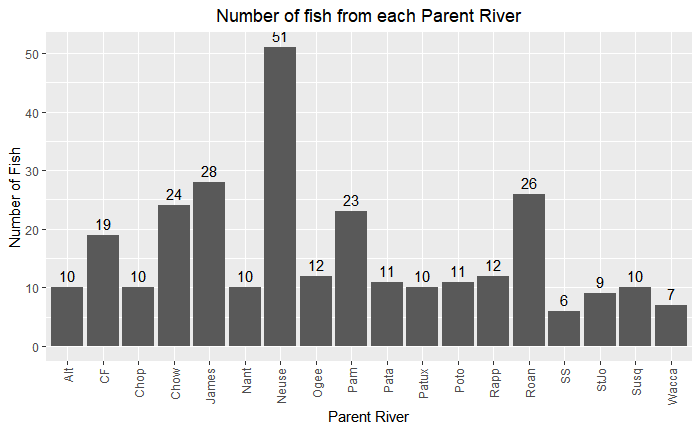

```r
fwdata%>%
  group_by(ParentRiver)%>%
  summarise(Count = n_distinct(Fishno))%>%
  ggplot(aes(x=ParentRiver, y=Count))+
  geom_bar(stat="identity")+
  geom_text(aes(label = Count), vjust = -0.5)+
  theme(axis.text.x = element_text(angle = 90, hjust = 1, vjust = 0.5))+
  labs(x="Parent River", y="Number of Fish")+
  ggtitle("Number of fish from each Parent River")+
  theme(plot.title = element_text(hjust = 0.5))
```

Rename the element columns

```r
colnames(fwdata)[5:11] <- c("Mg","Mn","Sr","Ba","Zn","Pb","Cu")
```

We know what river each of these fish were captured in, but we dont know which river they were born in. Therefore, when investigating early life element signatures, we cant assign hard labels to the data points. We want to know if fish that were captured in the same locations have similar element signatures in the early life regions of their otoliths, which would indicate they were likely born in the same locations and were returning there to spawn. - This assumes that water chemistry is relatively stable over time

Lets check out the distribution of each element

```r
library(ggpubr)
```

Make qqplots

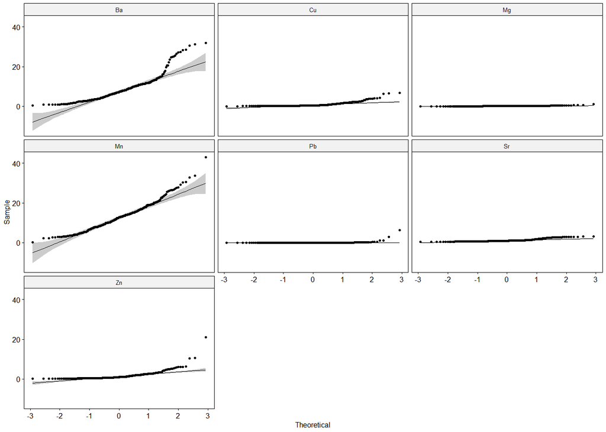

```r
fwdata%>%
  pivot_longer(-c(1:4), names_to = 'element', values_to='value')%>%
  ggqqplot(., x='value', facet.by = 'element')
```

There are some concerning data points, im going to apply a square root transformation to approach normality and control the variance.

```r
fwdata[,5:11] <- sqrt(fwdata[,5:11])
```

Run Pearson’s correlation, ill use the rquery.cormat function

|  | Sr | Mg | Zn | Pb | Cu | Mn | Ba |
| --- | --- | --- | --- | --- | --- | --- | --- |
| Sr | 1 |  |  |  |  |  |  |
| Mg | -0.19 | 1 |  |  |  |  |  |
| Zn | -0.09 | 0.67 | 1 |  |  |  |  |
| Pb | -0.075 | 0.3 | 0.44 | 1 |  |  |  |
| Cu | -0.21 | 0.34 | 0.66 | 0.56 | 1 |  |  |
| Mn | -0.43 | -0.0091 | 0.023 | 0.045 | 0.18 | 1 |  |
| Ba | 0.0076 | 0.34 | 0.21 | 0.022 | 0.058 | 0.24 | 1 |

|  | Sr | Mg | Zn | Pb | Cu | Mn | Ba |
| --- | --- | --- | --- | --- | --- | --- | --- |
| Sr | 0 |  |  |  |  |  |  |
| Mg | 0.0016 | 0 |  |  |  |  |  |
| Zn | 0.13 | 4.3e-39 | 0 |  |  |  |  |
| Pb | 0.2 | 1.8e-07 | 2.9e-15 | 0 |  |  |  |
| Cu | 0.00028 | 2.2e-09 | 7.8e-38 | 1.4e-25 | 0 |  |  |
| Mn | 1.5e-14 | 0.88 | 0.69 | 0.45 | 0.0025 | 0 |  |
| Ba | 0.9 | 2.7e-09 | 0.00033 | 0.71 | 0.32 | 4.7e-05 | 0 |

```
$sym
   Sr Mg Zn Pb Cu Mn Ba
Sr 1
Mg    1
Zn    ,  1
Pb       .  1
Cu    .  ,  .  1
Mn .              1
Ba    .              1
attr(,"legend")
[1] 0 ‘ ’ 0.3 ‘.’ 0.6 ‘,’ 0.8 ‘+’ 0.9 ‘*’ 0.95 ‘B’ 1
```

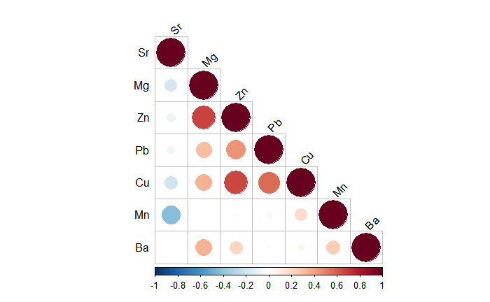

```r
source("http://www.sthda.com/upload/rquery_cormat.r")
rquery.cormat(fwdata[,5:11])
```

There are some troublesome correlations between Zn, Cu, and Pb - lets start by doing a pca and see if any of these seem to be unimportant variables

- ill use the factoextra package to do PCA

```r
library(FactoMineR)
library(factoextra)
```

```r
library(knitr)
```

```r
pca<-PCA(fwdata[,5:11], scale.unit = T, ncp = 7, graph = F)
```

```r
#get results for variables
pca.vars <- get_pca_var(pca)
#get results for individuals
individs <- get_pca_ind(pca)
#get eigenvalues
eigs<-round(pca$eig,2)
```

```r
kable(eigs)
```

|  | eigenvalue | percentage of variance | cumulative percentage of variance |
| --- | --- | --- | --- |
| comp 1 | 2.66 | 37.93 | 37.93 |
| comp 2 | 1.40 | 19.98 | 57.91 |
| comp 3 | 1.14 | 16.23 | 74.14 |
| comp 4 | 0.75 | 10.78 | 84.92 |
| comp 5 | 0.50 | 7.12 | 92.03 |
| comp 6 | 0.37 | 5.27 | 97.31 |
| comp 7 | 0.19 | 2.69 | 100.00 |

```r
kable(round(pca.vars$contrib,2))
```

|  | Dim.1 | Dim.2 | Dim.3 | Dim.4 | Dim.5 | Dim.6 | Dim.7 |
| --- | --- | --- | --- | --- | --- | --- | --- |
| Mg | 20.64 | 1.35 | 12.04 | 23.54 | 2.49 | 17.19 | 22.75 |
| Mn | 2.25 | 50.59 | 0.02 | 13.25 | 5.87 | 27.91 | 0.11 |
| Sr | 3.98 | 36.51 | 6.64 | 27.78 | 8.64 | 13.65 | 2.80 |
| Ba | 4.16 | 3.37 | 59.05 | 11.39 | 3.88 | 17.74 | 0.41 |
| Zn | 28.00 | 4.43 | 0.45 | 2.00 | 16.24 | 0.82 | 48.06 |
| Pb | 16.63 | 3.50 | 11.82 | 17.31 | 46.58 | 2.57 | 1.58 |
| Cu | 24.34 | 0.24 | 9.98 | 4.74 | 16.31 | 20.12 | 24.28 |

Plot the eigenvalues, and then variable contributions to the first 3 dimensions

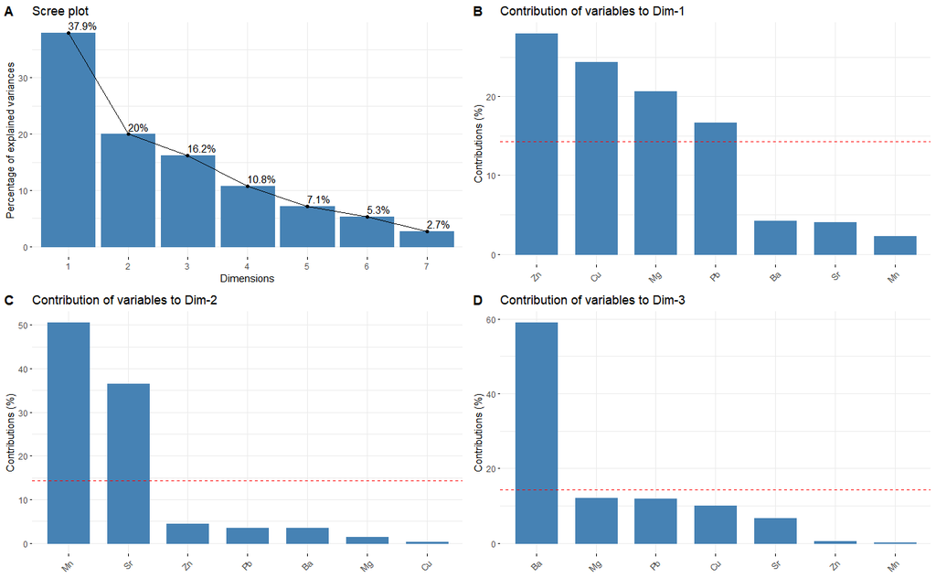

```r
eig.plot <- fviz_eig(pca, addlabels = T)#eigenvalues
vc.pc1 <- fviz_contrib(pca, choice = "var", axes = 1, top = 10)#var contribs to pc1
vc.pc2 <- fviz_contrib(pca, choice = "var", axes = 2, top = 10)#var contribs to pc2
vc.pc3 <- fviz_contrib(pca, choice = "var", axes = 3, top = 10)#var contribs to pc3
cowplot::plot_grid(eig.plot, vc.pc1, vc.pc2, vc.pc3, labels = "AUTO", nrow = 2)
```

Plot variable contributions to each pc

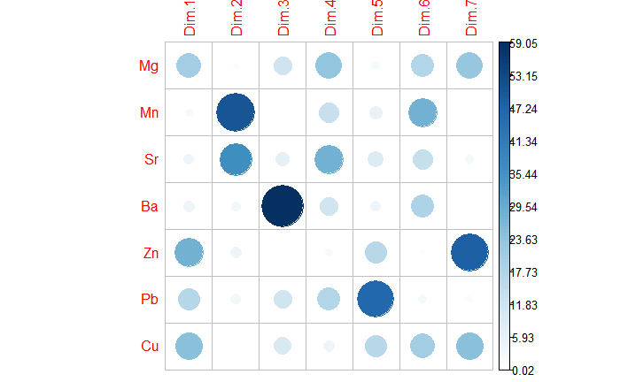

```r
corrplot(pca.vars$contrib, is.corr = F)#variable contributions to each pc
```

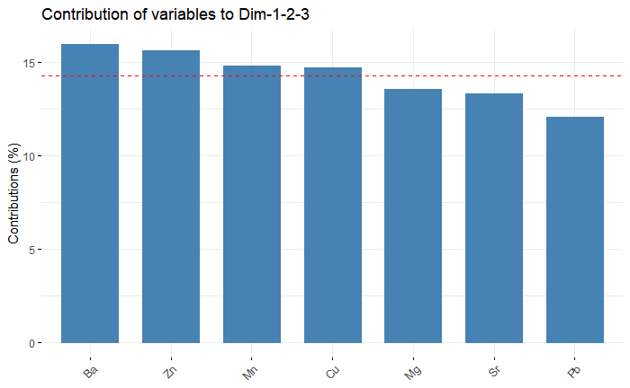

```r
fviz_contrib(pca, choice = "var", axes = 1:3, top = 10)
```

Lets use corrpot to view the quality of variable representation in each principle component

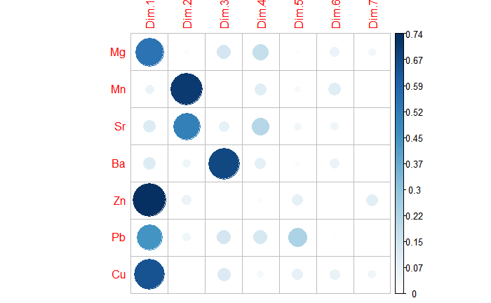

```r
corrplot(pca.vars$cos2, is.corr=F)
```

Now view the biplots of the first 3 dimensions

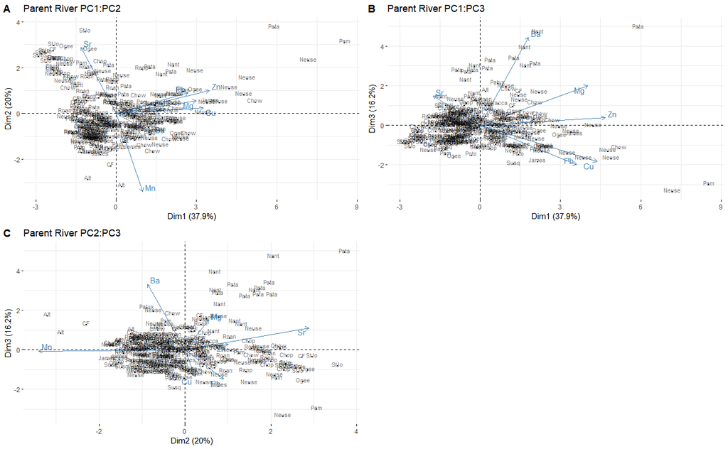

```r
p1vp2 <-
  fviz_pca_biplot(pca, geom.ind = "point", pointsize=0, repel = T)+
  ggtitle("Parent River PC1:PC2")+
  geom_text(aes(label = paste0(fwdata$ParentRiver)), alpha = 0.5, size = 3, nudge_y = 0.1, show.legend = FALSE)
p1vp3 <-
  fviz_pca_biplot(pca, axes=c(1,3), geom.ind = "point", pointsize=0, repel = T)+
  ggtitle("Parent River PC1:PC3")+
  geom_text(aes(label = paste0(fwdata$ParentRiver)), alpha = 0.5, size = 3, nudge_y = 0.1, show.legend = FALSE)
p2vp3<-
  fviz_pca_biplot(pca, axes = c(2,3), geom.ind = "point", pointsize=0, repel = T)+
  ggtitle("Parent River PC2:PC3")+
  geom_text(aes(label = paste0(fwdata$ParentRiver)), alpha = 0.5, size = 3, nudge_y = 0.1, show.legend = FALSE)
cowplot::plot_grid(p1vp2, p1vp3, p2vp3, labels = 'AUTO', nrow = 2)
```

Create Cu and Zn subsets

```r
Cu <- fwdata[,c(1:8,11)]
Zn <- fwdata[,c(1:9)]
```

Center and scale them

```r
Cu[,5:9] <- scale(Cu[,5:9])
Zn[,5:9] <- scale(Zn[,5:9])
```

```r
library(factoextra)
```

using the factoextra package calculate hopkins test statistic to evaluate the clustering tendency of the data

```r
get_clust_tendency(Cu[,5:9], n=nrow(Cu)-1, graph = F)$hopkins_stat
```

```
[1] 0.774731
```

```r
get_clust_tendency(Zn[,5:9], n=nrow(Zn)-1, graph = F)$hopkins_stat
```

```
[1] 0.778674
```

```
$hopkins_stat
[1] 0.774731

$plot
```

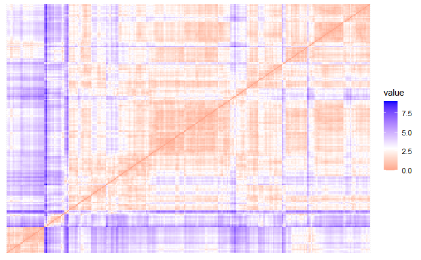

```r
get_clust_tendency(Cu[,5:9], n=nrow(Cu)-1, graph = T)
```

```
$hopkins_stat
[1] 0.778674

$plot
```

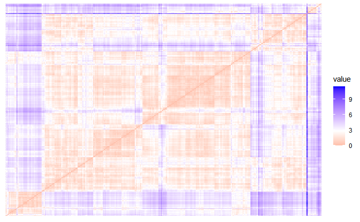

```r
get_clust_tendency(Zn[,5:9], n=nrow(Zn)-1, graph = T)
```

Now use the covRobust package to get a noise estimate, control for potential outliers using NNVE

```r
library(covRobust)
```

```r
noise.est.Cu<- cov.nnve(Cu[,5:9])
noise.Cu <- which(noise.est.Cu$classification==0)
noise.est.Zn<- cov.nnve(Zn[,5:9])
noise.Zn <- which(noise.est.Zn$classification==0)
```

Use the mclust package to do the GMMs

```r
library(mclust)
```

Use ICL to select the optimal covariance structure:

```r
set.seed(123)
icl.Cu <- mclustICL(Cu[,5:9], initialization = list(noise = as.numeric(noise.Cu)))
icl.Zn <- mclustICL(Zn[,5:9], initialization = list(noise = as.numeric(noise.Zn)))
```

```r
icl.Cu
```

```
Integrated Complete-data Likelihood (ICL) criterion:
        EII       VII       EEI       VEI       EVI       VVI       EEE
0 -5071.055 -5071.055 -5071.055 -5071.055 -5071.055 -5071.055 -5071.055
1 -3957.323 -3957.323 -3925.250 -3925.250 -3925.250 -3925.250 -3883.548
2 -3781.902 -3734.426 -3737.145 -3691.775 -3719.517 -3694.969 -3661.600
3 -3699.918 -3687.471 -3650.972 -3648.315 -3643.341 -3566.528 -3632.374
4 -3731.316 -3668.757 -3638.032 -3609.114 -3608.440 -3557.904 -3672.025
5 -3748.231 -3653.928 -3657.957 -3660.050 -3633.270 -3525.103 -3678.011
6 -3724.423 -3668.299 -3658.936 -3661.841 -3617.302 -3589.043 -3682.629
7 -3758.989 -3666.904 -3686.605 -3670.258 -3661.472 -3607.573 -3683.144
8 -3771.437 -3686.895 -3720.985 -3683.636 -3706.640 -3656.254 -3761.442
9 -3751.908 -3723.778 -3682.225 -3710.266 -3730.637 -3672.669 -3704.489
        EVE       VEE       VVE       EEV       VEV       EVV       VVV
0 -5071.055 -5071.055 -5071.055 -5071.055 -5071.055 -5071.055 -5071.055
1 -3883.564 -3883.548 -3883.564 -3883.548 -3883.548 -3883.548 -3883.548
2 -3663.525 -3620.659 -3616.383 -3686.204 -3637.341 -3668.695 -3659.899
3 -3602.034 -3612.395 -3517.683 -3655.292 -3592.505 -3678.810 -3599.966
4 -3618.568 -3619.407 -3579.890 -3667.653 -3620.257 -3732.044 -3671.974
5 -3606.288 -3653.036 -3618.803 -3693.847 -3670.659 -3767.274 -3732.466
6 -3748.587 -3670.264 -3693.083 -3733.355 -3684.424 -3815.763 -3770.305
7 -3581.085 -3670.953 -3702.077 -3764.640 -3829.470 -3882.868 -3922.427
8 -3694.528 -3695.219 -3637.959 -3818.834 -3892.162 -3983.629 -3970.918
9 -3779.820 -3708.124 -3779.649 -3905.219 -3927.135 -3999.631 -4019.214

Top 3 models based on the ICL criterion:
    VVE,3     VVI,5     VVI,4
-3517.683 -3525.103 -3557.904
```

```r
icl.Zn
```

```
Integrated Complete-data Likelihood (ICL) criterion:
        EII       VII       EEI       VEI       EVI       VVI       EEE
0 -5243.328 -5243.328 -5243.328 -5243.328 -5243.328 -5243.328 -5243.328
1 -3917.864 -3917.864 -3897.949 -3897.949 -3897.949 -3897.949 -3774.238
2 -3730.615 -3688.508 -3696.261 -3653.469 -3698.277 -3661.315 -3554.683
3 -3645.468 -3636.713 -3564.548 -3546.290 -3568.845 -3518.757 -3540.218
4 -3662.568 -3622.614 -3577.302 -3513.344 -3574.484 -3501.184 -3547.886
5 -3663.250 -3597.163 -3556.132 -3528.142 -3583.163 -3573.027 -3555.907
6 -3664.783 -3618.418 -3570.305 -3497.807 -3611.757 -3561.877 -3665.072
7 -3671.588 -3617.666 -3611.028 -3576.207 -3604.221 -3658.235 -3647.162
8 -3659.484 -3637.803 -3613.080 -3633.431 -3660.062 -3660.217 -3700.884
9 -3667.734 -3664.175 -3623.399 -3649.079 -3695.450 -3659.718 -3686.249
        EVE       VEE       VVE       EEV       VEV       EVV       VVV
0 -5243.328 -5243.328 -5243.328 -5243.328 -5243.328 -5243.328 -5243.328
1 -3774.239 -3774.238 -3774.239 -3774.238 -3774.238 -3774.238 -3774.238
2 -3568.318 -3524.828 -3522.332 -3588.136 -3546.488 -3572.542 -3566.817
3 -3547.742 -3518.333 -3498.457 -3586.119 -3546.083 -3620.644 -3568.959
4 -3528.470 -3531.197 -3535.727 -3625.760 -3596.761 -3684.678 -3629.439
5 -3561.460 -3551.738 -3527.172 -3638.497 -3637.040 -3724.201 -3691.332
6 -3582.532 -3594.134 -3628.915 -3680.594 -3673.401 -3715.046 -3743.948
7 -3629.971 -3605.136 -3669.718 -3750.563 -3748.926 -3817.855 -3845.329
8 -3642.012 -3635.469 -3684.058 -3801.440 -3812.742 -3888.512 -3921.107
9 -3617.726 -3656.548 -3714.660 -3846.620 -3847.827 -3919.124 -3932.696

Top 3 models based on the ICL criterion:
    VEI,6     VVE,3     VVI,4
-3497.807 -3498.457 -3501.184
```

```r
par(mfrow=c(1,2))
plot(icl.Cu)
plot(icl.Zn)
```

[figure not shown]

```r
par(mfrow=c(1,1))
```

```r
set.seed(123)
LRT.Cu<-mclustBootstrapLRT(Cu[,5:9], modelName = "VVE")
LRT.Zn<-mclustBootstrapLRT(Zn[,5:9], modelName = "VEI")
```

```r
LRT.Cu
```

```
-------------------------------------------------------------
Bootstrap sequential LRT for the number of mixture components
-------------------------------------------------------------
Model        = VVE
Replications = 999
```

|  | LRTS | bootstrap p-value |
| --- | --- | --- |
| 1 vs 2 | 263.58760 | 0.001 |
| 2 vs 3 | 284.41457 | 0.001 |
| 3 vs 4 | 74.92146 | 0.001 |
| 4 vs 5 | 91.71991 | 0.001 |
| 5 vs 6 | 27.87883 | 0.138 |

```r
LRT.Zn
```

```
-------------------------------------------------------------
Bootstrap sequential LRT for the number of mixture components
-------------------------------------------------------------
Model        = VEI
Replications = 999
```

|  | LRTS | bootstrap p-value |
| --- | --- | --- |
| 1 vs 2 | 335.22691 | 0.001 |
| 2 vs 3 | 270.21921 | 0.001 |
| 3 vs 4 | 69.40402 | 0.001 |
| 4 vs 5 | 134.46157 | 0.001 |
| 5 vs 6 | 9.99863 | 0.628 |

Make plots for the bootstrapped LRTs:

```r
par(mfrow = c(3,2))
plot(LRT.Cu, G=1)
plot(LRT.Cu, G=2)
```

```r
plot(LRT.Cu, G=3)
plot(LRT.Cu, G=4)
```

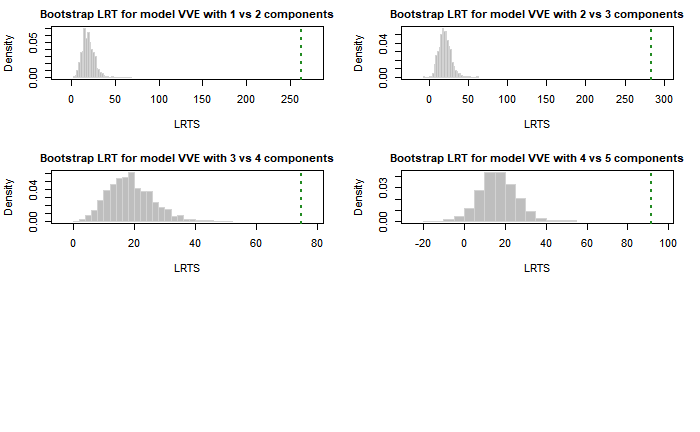

```r
plot(LRT.Cu, G=5)
```

[output not shown]

```r
par(mfrow = c(3,2))
plot(LRT.Zn, G=1)
plot(LRT.Zn, G=2)
```

```r
plot(LRT.Zn, G=3)
plot(LRT.Zn, G=4)
```

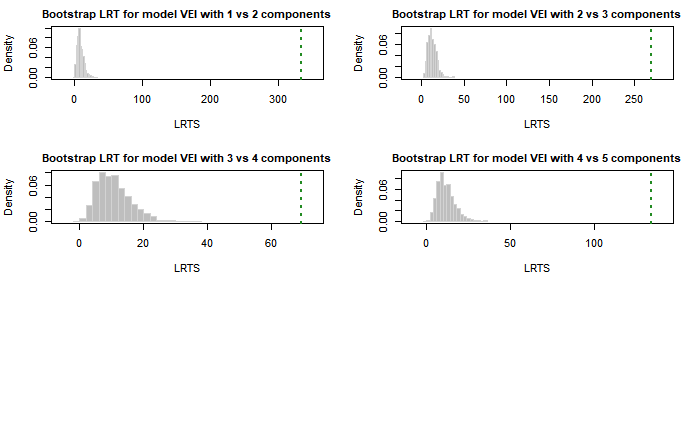

```r
plot(LRT.Zn, G=5)
```

[output not shown]

Fit the models

```r
mod.Cu <- Mclust(Cu[,5:9], G=5, modelNames = "VVE")
mod.Zn <- Mclust(Zn[,5:9], G=5, modelNames = "VEI")
```

```r
summary(mod.Cu, parameters = T)
```

```
----------------------------------------------------
Gaussian finite mixture model fitted by EM algorithm
----------------------------------------------------

Mclust VVE (ellipsoidal, equal orientation) model with 5 components:
```

|  | log-likelihood | n | df | BIC | ICL |
| --- | --- | --- | --- | --- | --- |
|  | -1593.383 | 289 | 64 | -3549.418 | -3617.479 |

```
Clustering table:
  1   2   3   4   5
 27 120  42  70  30

Mixing probabilities:
        1         2         3         4         5
0.0904605 0.4244909 0.1614932 0.2193904 0.1041651

Means:
         [,1]        [,2]       [,3]       [,4]       [,5]
Mg -0.3550140  0.17310793  1.2180717 -0.6027420 -1.0161037
Mn  0.2141685  0.15854646 -0.3594453  0.4616606 -1.2471671
Sr -0.9032814 -0.36905681  0.3451007 -0.1886973  2.1508124
Ba -0.8688787  0.04817876  0.9345210  0.2160252 -1.3456036
Cu -0.6951905  0.27134165  0.8780821 -0.6149988 -0.5680814

Variances:
[,,1]
              Mg          Mn            Sr           Ba            Cu
Mg  0.1084223493 0.005847932  0.0006720919  0.008399274 -0.0001797796
Mn  0.0058479318 0.188704871  0.0174690460  0.074700612  0.0251795410
Sr  0.0006720919 0.017469046  0.0771385022 -0.013522738  0.0091665155
Ba  0.0083992736 0.074700612 -0.0135227381  0.099014696  0.0218015880
Cu -0.0001797796 0.025179541  0.0091665155  0.021801588  0.0502468818
[,,2]
            Mg         Mn          Sr          Ba          Cu
Mg  0.41049038 0.05856232 -0.01737067  0.03237458  0.02229004
Mn  0.05856232 1.12787955  0.00350536  0.38263878  0.18773259
Sr -0.01737067 0.00350536  0.35831593  0.15864171 -0.08382596
Ba  0.03237458 0.38263878  0.15864171  0.70105539 -0.03408361
Cu  0.02229004 0.18773259 -0.08382596 -0.03408361  0.58183045
[,,3]
            Mg         Mn         Sr          Ba          Cu
Mg  2.16570696 -0.1579501 -0.2333234  0.01945996  0.05235086
Mn -0.15795005  0.5428829 -0.3465391 -0.49938584  0.37365111
Sr -0.23332336 -0.3465391  0.9057191  0.88916113 -0.89996611
Ba  0.01945996 -0.4993858  0.8891611  1.50094516 -1.22793164
Cu  0.05235086  0.3736511 -0.8999661 -1.22793164  2.18596706
[,,4]
            Mg         Mn         Sr         Ba          Cu
Mg 0.050421512 0.03547386 0.01126020 0.00360954 0.008258029
Mn 0.035473861 0.44246503 0.01464253 0.14616113 0.044098247
Sr 0.011260200 0.01464253 0.17589270 0.01504833 0.011308879
Ba 0.003609540 0.14616113 0.01504833 0.26311672 0.042319364
Cu 0.008258029 0.04409825 0.01130888 0.04231936 0.196293082
[,,5]
             Mg         Mn            Sr         Ba           Cu
Mg 0.0915136583 0.02502704  0.0008884693 0.01119348  0.006389198
Mn 0.0250270352 0.38905888  0.0135616332 0.15277194  0.058522345
Sr 0.0008884693 0.01356163  0.1074682269 0.02687401 -0.004735239
Ba 0.0111934789 0.15277194  0.0268740080 0.20865679  0.021516731
Cu 0.0063891979 0.05852235 -0.0047352389 0.02151673  0.142256989
```

```r
summary(mod.Zn, parameters = T)
```

```
----------------------------------------------------
Gaussian finite mixture model fitted by EM algorithm
----------------------------------------------------

Mclust VEI (diagonal, equal shape) model with 5 components:
```

|  | log-likelihood | n | df | BIC | ICL |
| --- | --- | --- | --- | --- | --- |
|  | -1643.206 | 289 | 38 | -3501.736 | -3558.416 |

```
Clustering table:
 1  2  3  4  5
40 94 94 32 29

Mixing probabilities:
        1         2         3         4         5
0.1432543 0.3191299 0.3147198 0.1222456 0.1006504

Means:
          [,1]         [,2]       [,3]       [,4]       [,5]
Mg -0.43261068  0.558873195 -0.4545009  1.0446279 -1.0038768
Mn -0.07759489  0.235031630  0.4009376 -0.5090292 -1.2702016
Sr -0.83142096 -0.425619420 -0.1761826  0.7783574  2.1383920
Ba -0.80636579 -0.002023466  0.3625935  1.1474219 -1.3732840
Zn -0.62878350  0.694693659 -0.5945700  1.0684106 -0.7462183

Variances:
[,,1]
          Mg        Mn        Sr        Ba        Zn
Mg 0.1335779 0.0000000 0.0000000 0.0000000 0.0000000
Mn 0.0000000 0.3520771 0.0000000 0.0000000 0.0000000
Sr 0.0000000 0.0000000 0.1123186 0.0000000 0.0000000
Ba 0.0000000 0.0000000 0.0000000 0.1532114 0.0000000
Zn 0.0000000 0.0000000 0.0000000 0.0000000 0.1268945
[,,2]
          Mg      Mn        Sr        Ba        Zn
Mg 0.3805908 0.00000 0.0000000 0.0000000 0.0000000
Mn 0.0000000 1.00314 0.0000000 0.0000000 0.0000000
Sr 0.0000000 0.00000 0.3200186 0.0000000 0.0000000
Ba 0.0000000 0.00000 0.0000000 0.4365305 0.0000000
Zn 0.0000000 0.00000 0.0000000 0.0000000 0.3615485
[,,3]
          Mg        Mn        Sr        Ba        Zn
Mg 0.1876057 0.0000000 0.0000000 0.0000000 0.0000000
Mn 0.0000000 0.4944804 0.0000000 0.0000000 0.0000000
Sr 0.0000000 0.0000000 0.1577476 0.0000000 0.0000000
Ba 0.0000000 0.0000000 0.0000000 0.2151802 0.0000000
Zn 0.0000000 0.0000000 0.0000000 0.0000000 0.1782191
[,,4]
         Mg       Mn       Sr       Ba       Zn
Mg 1.763723 0.000000 0.000000 0.000000 0.000000
Mn 0.000000 4.648721 0.000000 0.000000 0.000000
Sr 0.000000 0.000000 1.483021 0.000000 0.000000
Ba 0.000000 0.000000 0.000000 2.022957 0.000000
Zn 0.000000 0.000000 0.000000 0.000000 1.675477
[,,5]
         Mg        Mn        Sr        Ba        Zn
Mg 0.146698 0.0000000 0.0000000 0.0000000 0.0000000
Mn 0.000000 0.3866583 0.0000000 0.0000000 0.0000000
Sr 0.000000 0.0000000 0.1233506 0.0000000 0.0000000
Ba 0.000000 0.0000000 0.0000000 0.1682598 0.0000000
Zn 0.000000 0.0000000 0.0000000 0.0000000 0.1393582
```

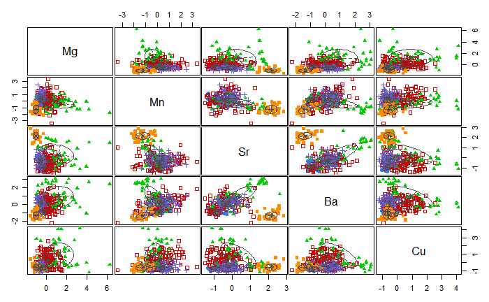

```r
plot(mod.Cu, what = "classification")
```

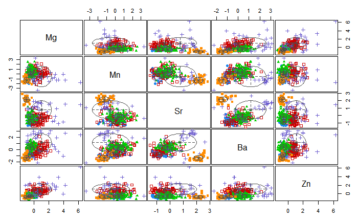

```r
plot(mod.Zn, what = "classification")
```

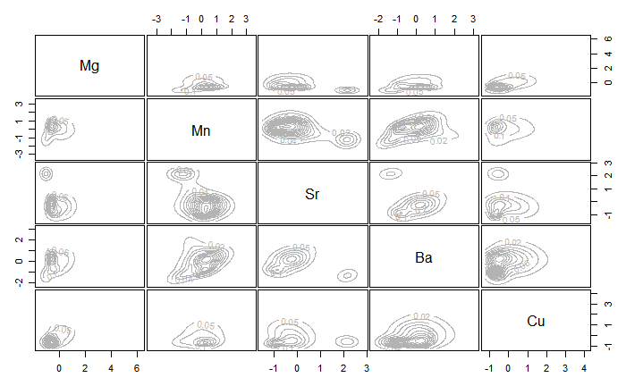

```r
plot(mod.Cu, what = "density")
```

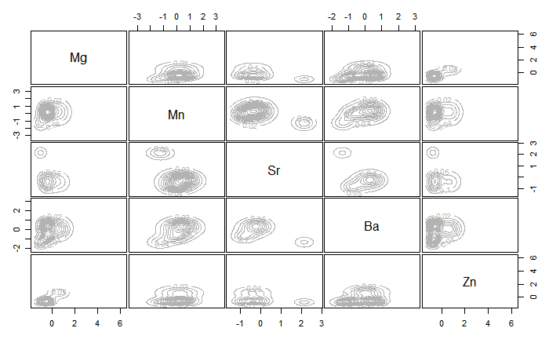

```r
plot(mod.Zn, what = "density")
```

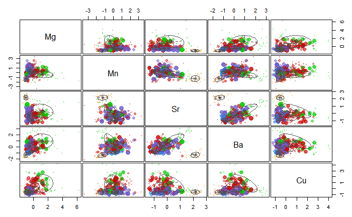

```r
plot(mod.Cu, what = "uncertainty")
```

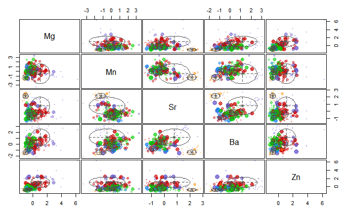

```r
plot(mod.Zn, what = "uncertainty")
```

Lets check out observations with high uncertainty:

```r
head(sort(mod.Cu$uncertainty, decreasing = T), 20)
```

```
 [1] 0.5069872 0.5067043 0.4989612 0.4890736 0.4864187 0.4623803
 [7] 0.4591506 0.4491531 0.4423484 0.4299453 0.4210752 0.4056330
[13] 0.4002706 0.3968741 0.3895931 0.3826199 0.3802543 0.3799022
[19] 0.3677398 0.3576600
```

```r
head(sort(mod.Zn$uncertainty, decreasing = T), 20)
```

```
 [1] 0.5843236 0.5327002 0.5053213 0.5018683 0.4958107 0.4877935
 [7] 0.4808822 0.4742257 0.4583278 0.4534587 0.4400155 0.4219668
[13] 0.4179409 0.4132621 0.4130333 0.4083541 0.4002113 0.3999195
[19] 0.3737369 0.3423056
```

- Most were less than 50%

Bootstrap the models using bs and wlbs

```r
set.seed(123)
boot.Cu <- MclustBootstrap(mod.Cu, type = "bs")
boot.Zn <- MclustBootstrap(mod.Zn, type = "bs")
wlboot.Cu <- MclustBootstrap(mod.Cu, nboot = 999, type = "wlbs")
wlboot.Zn <- MclustBootstrap(mod.Zn, nboot = 999, type = "wlbs")
```

Now calculate bootstrap standard errors and confidence intervals - Compare results using a nonparametric bootstrap and a weighted likelihood bootstrap

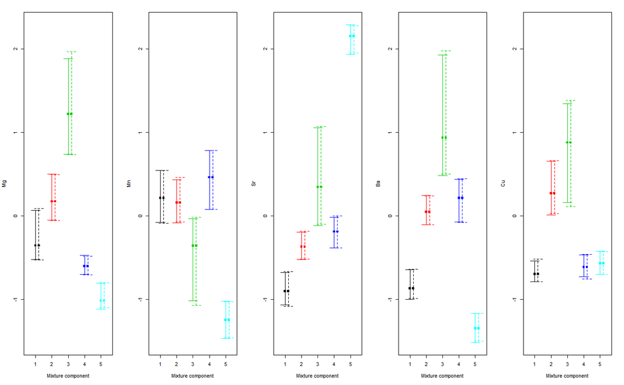

```r
boot.ci.Cu <- summary(boot.Cu, what = "ci")
wlboot.ci.Cu <- summary(wlboot.Cu, what = "ci")
par(mfrow = c(1,5))
for(j in 1:mod.Cu$G) {
  plot(1:mod.Cu$G, mod.Cu$parameters$mean[j,], col = 1:mod.Cu$G, pch = 15,
       ylab = colnames(Cu[,5:9])[j],
       xlab = "Mixture component",
       ylim = range(boot.ci.Cu$mean,wlboot.ci.Cu$mean),
       xlim = c(.5,mod.Cu$G+.5), xaxt = "n")
  points(1:mod.Cu$G+0.2, mod.Cu$parameters$mean[j,], col = 1:mod.Cu$G, pch = 15)
  axis(side = 1, at = 1:mod.Cu$G)
  with(boot.ci.Cu, errorBars(1:G, mean[1,j,], mean[2,j,], col = 1:G))
  with(wlboot.ci.Cu, errorBars(1:G+0.2, mean[1,j,], mean[2,j,], col = 1:G, lty = 2)) }
```

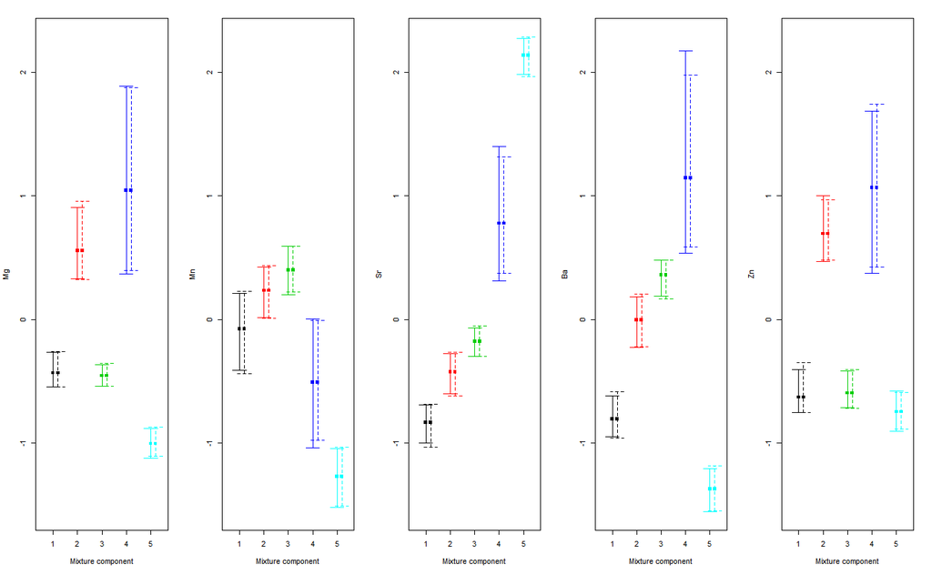

```r
boot.ci.Zn <- summary(boot.Zn, what = "ci")
wlboot.ci.Zn <- summary(wlboot.Zn, what = "ci")
par(mfrow = c(1,5))
for(j in 1:mod.Zn$G) {
  plot(1:mod.Zn$G, mod.Zn$parameters$mean[j,], col = 1:mod.Zn$G, pch = 15,
       ylab = colnames(Zn[,5:9])[j],
       xlab = "Mixture component",
       ylim = range(boot.ci.Zn$mean,wlboot.ci.Zn$mean),
       xlim = c(.5,mod.Zn$G+.5), xaxt = "n")
  points(1:mod.Zn$G+0.2, mod.Zn$parameters$mean[j,], col = 1:mod.Zn$G, pch = 15)
  axis(side = 1, at = 1:mod.Zn$G)
  with(boot.ci.Zn, errorBars(1:G, mean[1,j,], mean[2,j,], col = 1:G))
  with(wlboot.ci.Zn, errorBars(1:G+0.2, mean[1,j,], mean[2,j,], col = 1:G, lty = 2)) }
par(mfrow = c(1,1))
```

The difference is negligable so ill just report the regular bootstrap

Plot mixing proportions:

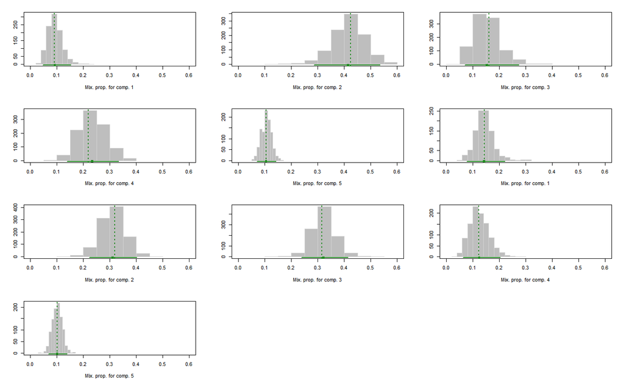

```r
par(mfrow = c(4,3))
plot(boot.Cu, what = "pro")
plot(boot.Zn, what = "pro")
```

Add a cluster column to the data to identify which cluster each fish was assigned to

```r
Cu <- cbind(Cu, mod.Cu$classification)
Zn <- cbind(Zn, mod.Zn$classification)
names(Cu)[10] <- "cluster"
names(Zn)[10] <- "cluster"
```

Im going to use the names a and b to manipulate the Cu subset, and ill use c and d to manipulate the Zn subset

```r
a<-
Cu%>%
  dplyr::select(5:10)%>%
  dplyr::group_by(cluster)%>%
  summarise_all(mean)%>%
  pivot_longer(-c("cluster"), names_to = "Vars", values_to = "mean")

b<-summary(boot.Cu, what = "se")$mean
b <- as.data.frame(t(b))
b$cluster <- 1:5
b<-pivot_longer(b,-c("cluster"), names_to = "Vars", values_to = "mean")
a$SE <- b$mean
a$cluster <- as.factor(a$cluster)
c <- Zn%>%
  dplyr::select(5:10)%>%
  dplyr::group_by(cluster)%>%
  summarise_all(mean)%>%
  pivot_longer(-c("cluster"), names_to = "Vars", values_to = "mean")
d<-summary(boot.Zn, what = "se")$mean
d <- as.data.frame(t(d))
d$cluster <- 1:5
d<-pivot_longer(d,-c("cluster"), names_to = "Vars", values_to = "mean")
c$SE <- d$mean
c$cluster <- as.factor(c$cluster)
```

```r
a$Vars <- factor(a$Vars, levels = c("Sr", "Ba", "Mg", "Mn", "Cu"))
c$Vars <- factor(c$Vars, levels = c("Sr", "Ba", "Mg", "Mn", "Zn"))
col1 <- c("1" = "red", "2" = "blue", "3" = "black", "4" = "green", "5" = "purple")
col2 <- c("1" = "red", "2" = "blue", "3" = "green", "4" = "black", "5" = "purple")
p1<-
ggplot(a, aes(x=Vars, y=mean, group=cluster)) +
  geom_line(aes(colour=cluster), show.legend = F)+
  geom_point()+
  scale_color_manual(values = col1)+
  geom_errorbar(aes(ymin=mean-SE, ymax=mean+SE), width = .1)+
    labs(title = "Cu Subset", x = "Element", y = "Cluster Average +/- SE")+
    theme_bw()+
  theme(plot.title = element_text(hjust = 0.5))
p2<-
ggplot(c, aes(x=Vars, y=mean, group=cluster)) +
  geom_line(aes(colour=cluster))+
  geom_point()+
  scale_color_manual(name = "Cluster", values = col2, labels = c("A","B","C","D","E"))+
  geom_errorbar(aes(ymin=mean-SE, ymax=mean+SE), width = .1)+
    labs(title = "Zn Subset", x = "Element", y = "Cluster Average +/- SE")+
    theme_bw() +
    theme(legend.justification=c(1,0),
          legend.position=c(1,0),# Position legend in bottom right
          plot.title = element_text(hjust = 0.5))
```

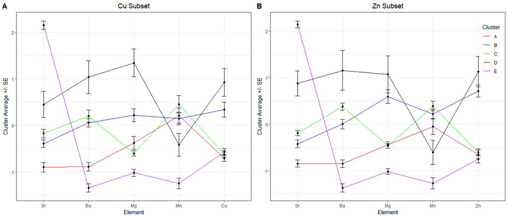

```r
cowplot::plot_grid(p1,p2, labels = "AUTO")
```

```r
Cu.sum<-
Cu%>%
  dplyr::count(ParentRiver, cluster)%>%
  group_by(ParentRiver)%>%
  mutate(n = n / sum(n))%>%
  pivot_wider(names_from = cluster, values_from = n)%>%
  inner_join(count(Cu, ParentRiver, name = "total"))
Cu.sum[,2:6] <- 100*Cu.sum[,2:6]
Cu.sum[,2:6] <- round(Cu.sum[,2:6],0)
Cu.sum[is.na(Cu.sum)] <- 0
#put these in correct order:
Cu.sum <- Cu.sum[,c(1,4,2,5,3,6,7)]


Zn.sum<-
Zn%>%
  count(ParentRiver, cluster)%>%
  group_by(ParentRiver)%>%
  mutate(n = n / sum(n))%>%
  pivot_wider(names_from = cluster, values_from = n)%>%
  inner_join(count(Zn, ParentRiver, name = "total"))
Zn.sum[,2:6] <- 100*Zn.sum[,2:6]
Zn.sum[,2:6] <- round(Zn.sum[,2:6],0)
Zn.sum[is.na(Zn.sum)] <- 0
#Put these in correct order:
Zn.sum <- Zn.sum[,c(1,4,5,2,3,6,7)]
```

So I know from making the previous plots that what the model named cluster 3 and 4 are flipped between the subsets: - Cluster 3 in the Cu subset has similar characteristics to cluster 4 in the Zn subset, and cluster 4 in the Cu subset has similar characteristics to cluster 3 in the Zn subset - thankfully the rest are fine

I want to make barplots to show the percent of each ParentRiver that was assigned to each cluster with similar elemental characteristics, so to fix the issue with clusters 3 and 4 I will just flip them when I assign letters to them:

```r
Cu.sum <- data.frame(Cu.sum)
colnames(Cu.sum)<- c("ParentRiver", "A", "B", "C", "D", "E", "total")
Cu.sum$ParentRiver <- factor(Cu.sum$ParentRiver, levels = c("Susq","Pata","Chop","Patux","Poto","Nant","Rapp","James","Chow","Roan","Pam","Neuse","CF","Wacca","SS","Ogee","Alt","StJo"))

Zn.sum <- data.frame(Zn.sum)
colnames(Zn.sum)<- c("ParentRiver", "A", "B", "D", "C", "E", "total")
Zn.sum$ParentRiver <- factor(Zn.sum$ParentRiver, levels = c("Susq","Pata","Chop","Patux","Poto","Nant","Rapp","James","Chow","Roan","Pam","Neuse","CF","Wacca","SS","Ogee","Alt","StJo"))
```

Now make the plots, each bar will show the original sample size from each ParentRiver, and the bars will be colored proportionally according to the percent of Hickory Shad that were assigned to each cluster of similar elemental characteristics

```r
Cu.barplot<-
Cu.sum %>%
   pivot_longer(-c(ParentRiver,total), names_to= "Cluster", values_to = "val") %>%
   mutate(val1 = val * total / 100)%>%
  ggplot(., aes(x=ParentRiver, y=val1, fill = Cluster))+
  geom_bar(stat = "identity", show.legend = F)+
  geom_text(aes(y = total, label = ifelse(Cluster == "A", total, "")), nudge_y = 2, size = 4)+
  geom_text(aes(y = val1,
                label = ifelse(val > 0, scales::percent(val, scale = 1, accuracy = 1), "")),
            position = position_stack(vjust = .6), size = 2.5)+
  labs(title = "Cu Subset",x="Parent River", y="Sample Size/Percent Cluster Assignment")+
  theme(plot.title = element_text(hjust = 0.5),
        axis.text.x = element_text(angle = 90, hjust = 1, vjust = 0.5),
        panel.background = element_rect(fill= "white"),
        axis.line = element_line(colour = 'black'))
Zn.barplot<-
Zn.sum%>%
   pivot_longer(-c(ParentRiver,total), names_to= "Cluster", values_to = "val") %>%
   mutate(val1 = val * total / 100)%>%
  ggplot(., aes(x=ParentRiver, y=val1, fill = Cluster))+
  geom_bar(stat = "identity")+
  geom_text(aes(y = total, label = ifelse(Cluster == "A", total, "")), nudge_y = 2, size = 4) +
  geom_text(aes(y = val1,
                label = ifelse(val > 0, scales::percent(val, scale = 1, accuracy = 1), "")),
            position = position_stack(vjust = .6), size = 2.5)+
  labs(title = "Zn Subset",x="Parent River", y="Sample Size/Percent Cluster Assignment")+
  theme(axis.text.x = element_text(angle = 90, hjust = 1, vjust = 0.5),
        plot.title = element_text(hjust = 0.5),
        panel.background = element_rect(fill= "white"),
        axis.line = element_line(colour = 'black'),
        legend.position = c(0.95,0.75))
```

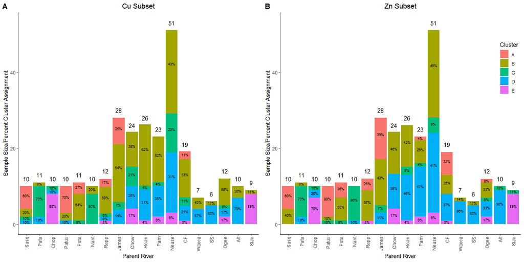

So in most cases, the majority of fish (>50%) from one river system were assigned to the same cluster, meaning fish from the same river systems had similar natal river element signatures

To confirm that their is a significant relationship between ParentRiver and cluster assignment, I am going to use a Chi-Square test of independence, and I will generate a distribution of 2000 Chi-Square test statistics to compare the observed value.

```r
chisq.test(Cu$ParentRiver, Cu$cluster)
```

```
Chi-squared approximation may be incorrect
```

```
    Pearson's Chi-squared test

data:  Cu$ParentRiver and Cu$cluster
X-squared = 337.99, df = 68, p-value < 2.2e-16
```

```r
chisq.test(Cu$ParentRiver, Cu$cluster, simulate.p.value = T)
```

```
    Pearson's Chi-squared test with simulated p-value (based on
    2000 replicates)

data:  Cu$ParentRiver and Cu$cluster
X-squared = 337.99, df = NA, p-value = 0.0004998
```

```r
chisq.test(Zn$ParentRiver, Zn$cluster)
```

```
Chi-squared approximation may be incorrect
```

```
    Pearson's Chi-squared test

data:  Zn$ParentRiver and Zn$cluster
X-squared = 385.95, df = 68, p-value < 2.2e-16
```

```r
chisq.test(Zn$ParentRiver, Zn$cluster, simulate.p.value = T)
```

```
    Pearson's Chi-squared test with simulated p-value (based on
    2000 replicates)

data:  Zn$ParentRiver and Zn$cluster
X-squared = 385.95, df = NA, p-value = 0.0004998
```